# Pitch for My Shiny App

1/22/2017

## Shiny App Introduction

This presentation is part of the John Hopkins Coursera Project for Developing Data Products.

The shiny app contains ui.R and Server.R. For more information about the code for my app, please refer to https://github.com/ttjxuan/ShinyApp

Also, you can open this app by clicking link https://ttjxuan.shinyapps.io/myshinyapp/

The code has been upload to github repo. My ShinyApp contains 4 tabs. First Tab you will see is the documentation. **It would give you initial idea how to use the App**. In the Following slides I will show the datasets and code I use. I am mainly going to focus on the tab3 since the tab 2 would be easy in math part and technique would be similar as they other two.

- Tab 1

## Tab 1

```r
library(plotly)
plot_ly(mtcars, x=mtcars$wt, y = mtcars$mpg, mode = "markers",color = as.factor(mtcars$cyl),size = mtcars$hp)
```

[interactive chart not shown]

## Tab 3

```
## 'data.frame':    50 obs. of  2 variables:
##  $ speed: num  4 4 7 7 8 9 10 10 10 11 ...
##  $ dist : num  2 10 4 22 16 10 18 26 34 17 ...
```

Use speed to predict the stop distance from this speed. You can choose any speed you want in this range from 4 to 25, and use three linear regression methods to predict the result. I add polynomial function as the third function.

```r
cars$spd1 <- ifelse(cars$speed - 12 > 0, cars$speed - 12, 0)
model1 <- lm(dist ~ speed, data = cars)
model2 <- lm(dist ~ spd1, data = cars)
model3 <- lm(dist ~ I(speed^3), data = cars)
```

Above is the code for the three models

## Tab 3

The app interface is like below. Thank you!

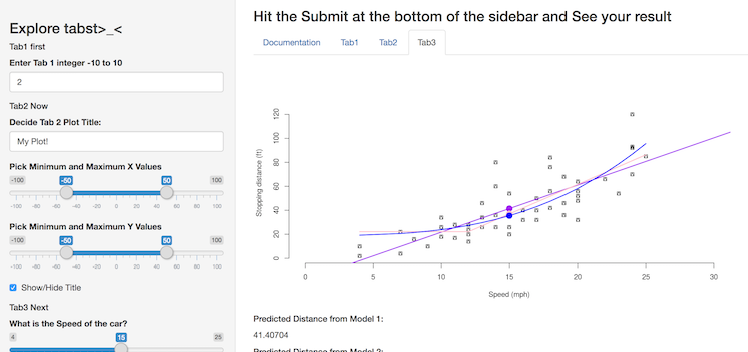